# Introduction to bar/column plots with ggplot2.

2024-01-06

## Data preparation

The data : Microbial family abundance by sample.

We have 131 samples taken on four different plant hosts (mosses) on either the brown or green compartment of the plant. For each microbial Family identified, the count represents the absolute number of sequences in a sample that were attributed to that Family. We want to compare these numbers across compartments and hosts.

First, let’s have a look at the data:

```r
# Import the data file
seq_count <- read.delim("../../Data/sequence_counts.tsv") # by default, read.delim assumes the file has a header, and that it is separated by tabulations ("\t")

head(seq_count) # Look at the data
```

```
##         Sample           Family          Host Compartment seq_count
## 1 S-1-DICUND-B Acetobacteraceae   D_undulatum       Brown       892
## 2 S-1-POLCOM-B Acetobacteraceae     P_commune       Brown     36597
## 3 S-1-POLCOM-G Acetobacteraceae     P_commune       Green     13313
## 4 S-1-POLJUN-B Acetobacteraceae P_juniperinum       Brown     15383
## 5 S-1-POLJUN-G Acetobacteraceae P_juniperinum       Green     27396
## 6 S-1-POLPIL-B Acetobacteraceae   P_piliferum       Brown     48578
```

How many samples do we have by host and compartment ?

```r
seq_count %>%
  select(Sample, Host, Compartment) %>% # ignore the seq_count and Family columns
  unique %>% # Keep one line per unique combinations of these variables
  dplyr::summarise(n_samples = n(), # count the number of samples for each
                   .by = c('Host', 'Compartment'))
```

```
##            Host Compartment n_samples
## 1   D_undulatum       Brown         8
## 2     P_commune       Brown         9
## 3     P_commune       Green         9
## 4 P_juniperinum       Brown        24
## 5 P_juniperinum       Green        22
## 6   P_piliferum       Brown        26
## 7   P_piliferum       Green        26
## 8   D_undulatum       Green         7
```

The columns whose values are not numbers are considered character columns. You can see this by looking at the structure of your object, where `chr` means character and `int` means integer.

```r
str(seq_count)
```

```
## 'data.frame':    1310 obs. of  5 variables:
##  $ Sample     : chr  "S-1-DICUND-B" "S-1-POLCOM-B" "S-1-POLCOM-G" "S-1-POLJUN-B" ...
##  $ Family     : chr  "Acetobacteraceae" "Acetobacteraceae" "Acetobacteraceae" "Acetobacteraceae" ...
##  $ Host       : chr  "D_undulatum" "P_commune" "P_commune" "P_juniperinum" ...
##  $ Compartment: chr  "Brown" "Brown" "Green" "Brown" ...
##  $ seq_count  : int  892 36597 13313 15383 27396 48578 21519 12566 33122 14588 ...
```

To work well with ggplot, we need them to be factors. You can see factors as a set of categories that represents each unique value in a variable. For example, we have two Compartment factors (Brown or Green). Here’s a quick way to convert all character columns to factors, using a little trick from the very useful `dplyr` package.

```r
seq_count <- seq_count %>%
  mutate(across(where(is.character), as.factor))

str(seq_count) # Making sure the factors are as expected
```

```
## 'data.frame':    1310 obs. of  5 variables:
##  $ Sample     : Factor w/ 131 levels "S-1-DICUND-B",..: 1 2 3 4 5 6 7 8 9 10 ...
##  $ Family     : Factor w/ 10 levels "Acetobacteraceae",..: 1 1 1 1 1 1 1 1 1 1 ...
##  $ Host       : Factor w/ 4 levels "D_undulatum",..: 1 2 2 3 3 4 3 3 4 4 ...
##  $ Compartment: Factor w/ 2 levels "Brown","Green": 1 1 2 1 2 1 1 2 1 2 ...
##  $ seq_count  : int  892 36597 13313 15383 27396 48578 21519 12566 33122 14588 ...
```

There, you can see that our four variables are now factors and you can validate the number of levels for each (good tip to find data errors!)

## Barplot

We want to look at how microbial families are distributed across our samples using their sequence counts. We’ll start very simple, by using the mean of all samples for each Family. For this, we need to do a short data manipulation, because right now our dataset has one observation per family *per sample*.

#### Barplot by microbial family

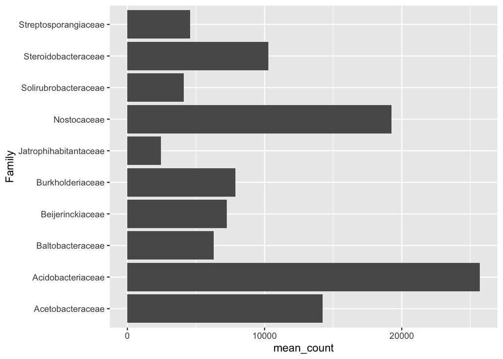

```r
# Dataframe
family.df <- seq_count %>%
  group_by(Family) %>%
  summarise(mean_count = mean(seq_count))

# Plot
ggplot(family.df,
       aes(x = mean_count, y = Family)
       ) +
  geom_col()
```

That’s nice, but now we’d like to see if these counts differ much across compartments, i.e. the green vs. the brown part of the plants. Therefore, we need to calculate the mean for each family. We’ll also compute the standard deviation of those means for later. The `fill` aesthetic will come in handy.

#### Multiple groups (stacked)

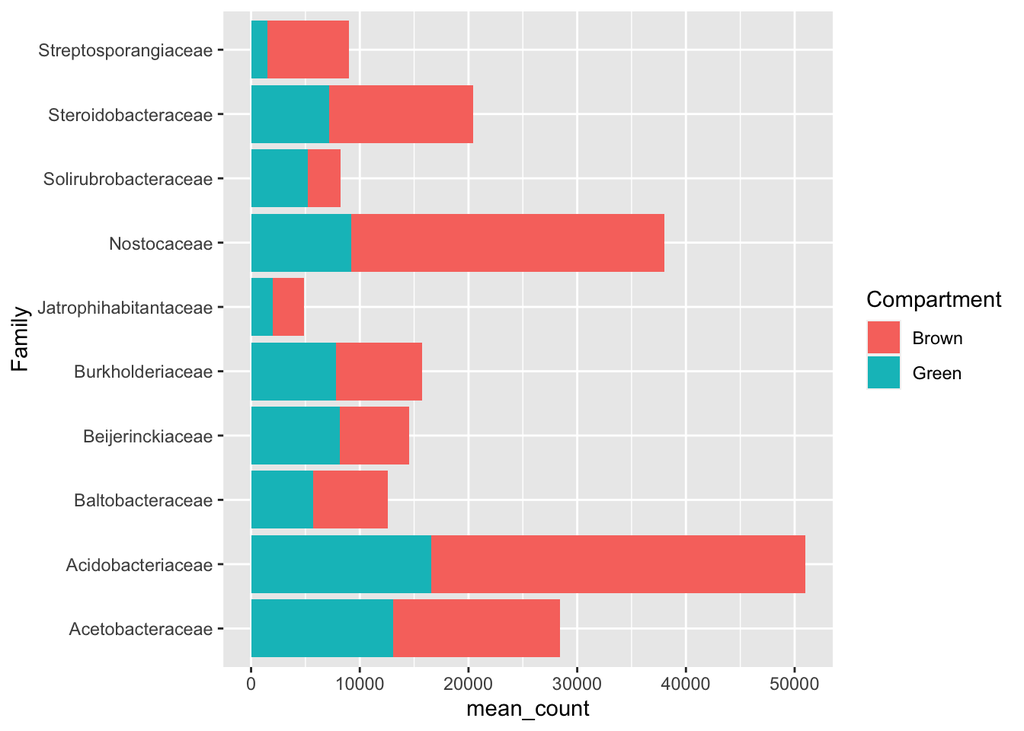

```r
# Dataframe
familyComp.df <- seq_count %>%
  group_by(Family, Compartment) %>%
  summarise(mean_count = mean(seq_count),
            sd_count = sd(seq_count),        # calculate SD
            .groups = 'drop')                # drops the grouping structure

# Plot
ggplot(familyComp.df,
       aes(x = mean_count, y = Family,
           fill = Compartment)) + # fill by compartment
  geom_col()
```

#### Multiple groups (dodged)

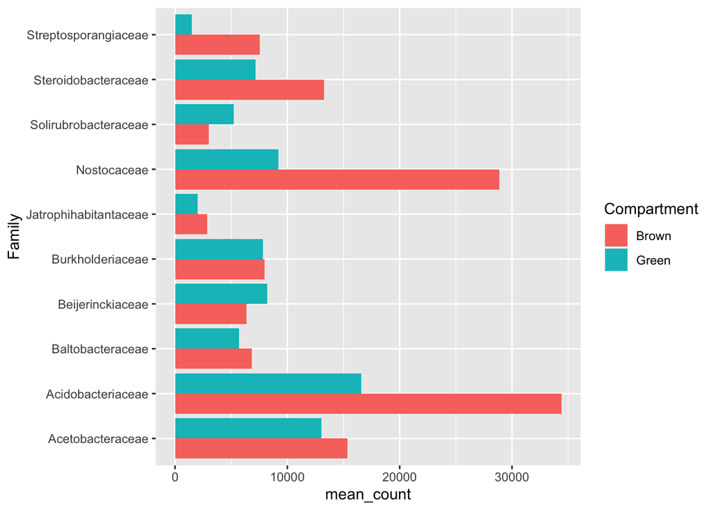

```r
ggplot(familyComp.df, aes(x = mean_count, y = Family, fill = Compartment)) +
  geom_col(position = "dodge") # Dodge the columns, so we can read the counts
```

That’s better. However, it could be useful to show how precise these means are. We can add the standard deviation of each as an error bar. Look carefully, we need to modify the `position` argument a bit so everything aligns properly:

#### Error bars

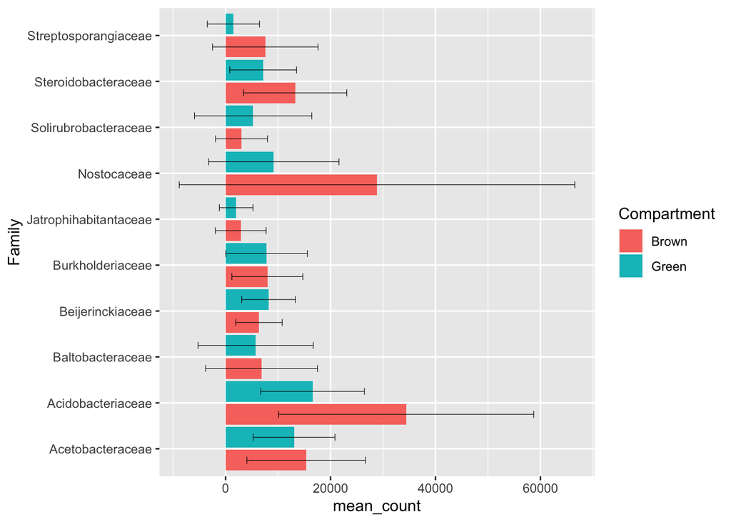

```r
ggplot(familyComp.df, aes(x = mean_count, y = Family, fill = Compartment)) +
  geom_col(position = position_dodge(width = 1)) + # slight modification
  geom_errorbar(aes(xmin = mean_count - sd_count,
                    xmax = mean_count + sd_count),
                width = 0.3, # size of the "caps"
                linewidth = 0.2, # thickness
                position = position_dodge(width = 1)) # same as in geom_col
```

Since plots are meant to be pretty, let’s do a couple more things:

1. Use some coherent colours (green and brown!)
2. Remove the gray background by imposing a minimal theme
3. Rename the x axis and add a plot title uning `labs()`
4. Remove the horizontal grid using `theme()`
5. Use a different font size and police

Since this will be our final plot for this exercise, we’ll also save it into an object in order to be able to export it.

#### Prettier barplot

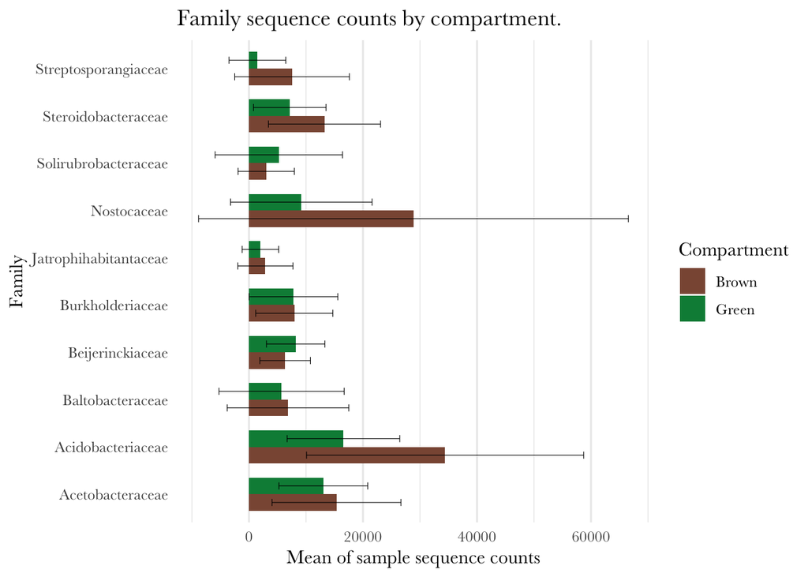

```r
comp_colours <- c("lightsalmon4", "springgreen4")

myplot <- # save this plot as an object
  ggplot(familyComp.df, aes(x = mean_count, y = Family, fill = Compartment)) +
  geom_col(position = position_dodge(width = 0.7), # cluster columns by family
           width = 0.7) + # readjust the columns so they don't overlap
  geom_errorbar(aes(xmin = mean_count - sd_count, xmax = mean_count + sd_count),
                width = 0.3, linewidth = 0.2, position = position_dodge(width = 0.7)) +
  scale_fill_manual(values = comp_colours) + # follows factor levels
  labs(title = "Family sequence counts by compartment.", # Title
       x = "Mean of sample sequence counts") + # meaningful label
  theme_minimal(base_family = "Baskerville", # new font, and this theme removes gray background
                base_size = 12) + # font size
  theme(panel.grid.major.y = element_blank()) # remove horizontal grid
myplot
```

Saving this plot can be easily achieved through `ggsave()`, which is pretty straightforward.

```r
ggsave(filename = "./barplot.jpg", plot = myplot,
       width = 1600, height = 900, units = 'px', dpi = 150)
```

### Exercise

Try to create a barplot with mean seq_count *by Host*, without specifying colours. Try applying a different theme (hint: type `?theme_` in your console and a semi-automatic selection appears with many themes to play around with). Add a caption to your plot to specify that we are using 131 samples, and change the legend label to something more explicit than “host”. (hint: look at the `labs()` function). Do not add error bars.

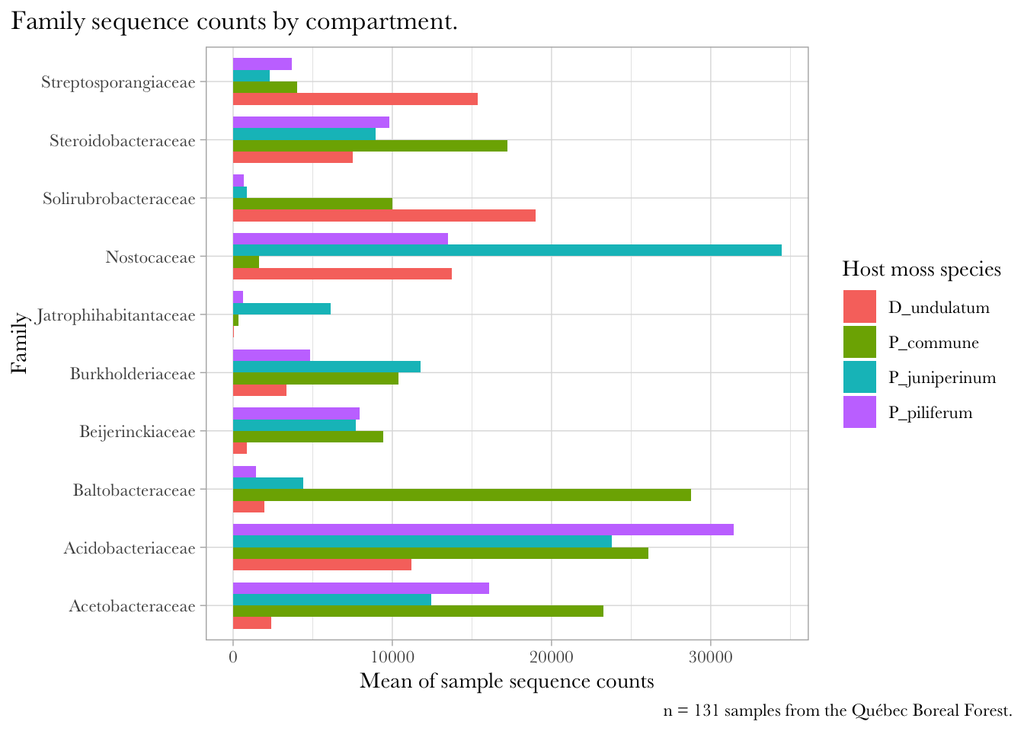

```r
seq_count %>%
  group_by(Family, Host) %>%
  summarise(mean_count = mean(seq_count),
            sd_count = sd(seq_count),        # calculate SD
            .groups = 'drop') %>%

ggplot(aes(x = mean_count, y = Family, fill = Host)) +
  geom_col(position = position_dodge(width = 0.8), # cluster columns by family
           width = 0.8) + # readjust the columns so they don't overlap
  labs(title = "Family sequence counts by compartment.", # Title
       x = "Mean of sample sequence counts",
       caption = "n = 131 samples from the Québec Boreal Forest.",
       fill = "Host moss species") + # meaningful label
  theme_light(base_family = "Baskerville") +
  theme(plot.caption.position = "plot", # sends it all the way to the right.
        plot.title.position = "plot") # Sends it all the way to the left
```

## Barplots with facets

A different way of looking at the data could be to compare Host and Compartment at the same time. To visualize the families across these two sample data, we can use faceting. Notice that we are back to the original (non-summarised) data.

In this case, we’ll start by plotting the counts for each compartment

#### Stacked barplot

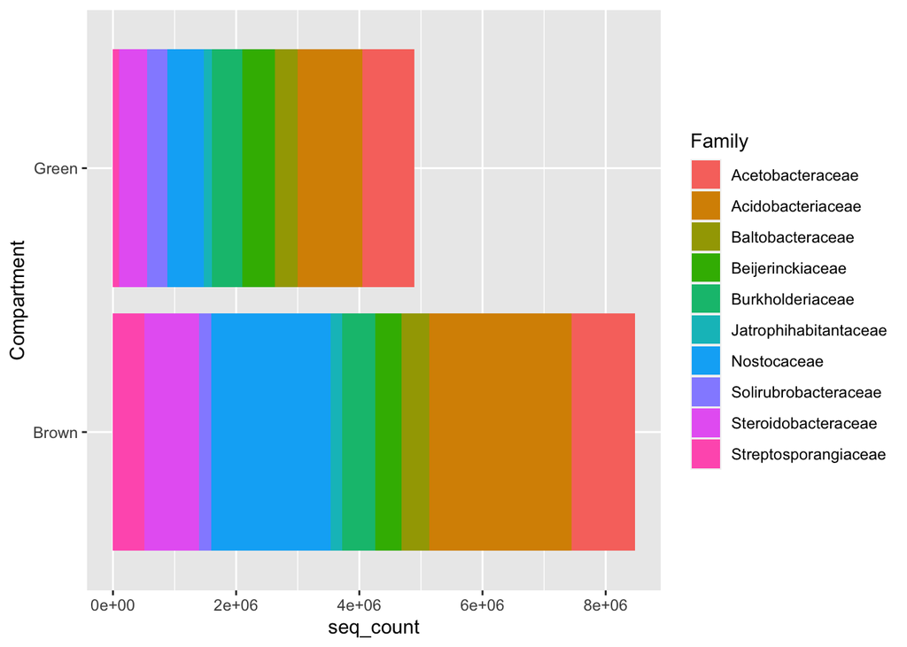

```r
ggplot(seq_count, aes(y = Compartment, x = seq_count)) +
  geom_col(aes(fill = Family))
```

```r
      # Notice: we don't use the "dodge" option, so the counts stack.
```

How can we look at each host separately? `facet_grid()` will help us !

#### Splitting by groups with Facets

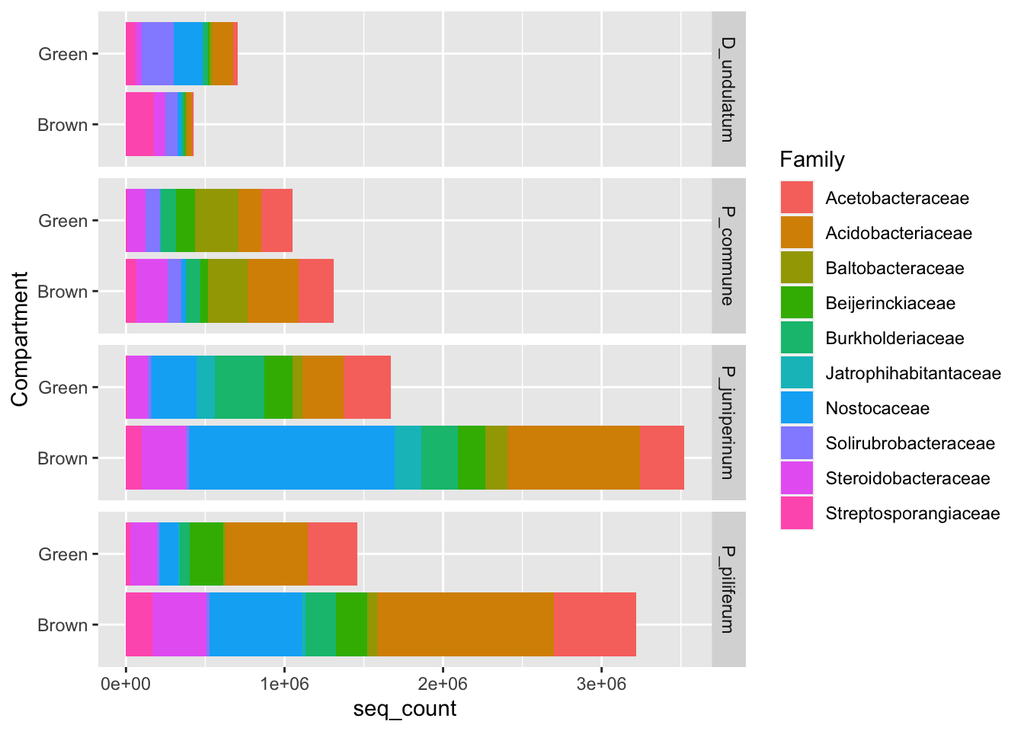

```r
ggplot(seq_count, aes(y = Compartment, x = seq_count)) +
  geom_col(aes(fill = Family)) +
    # This is where the magic happens:
  facet_grid(rows = vars(Host), # Adds facets
             scales="free") # allows different x-axis scales for each facet
```

That’s fine, but it reveals a weakness in the way we are presenting data. Indeed, the total number of sequences is often very different between compartments, making it hard to tell if some families are relatively more or less represented.

One way to solve this is to normalize the counts to 1, which is equivalent to showing the relative counts instead of the absolute counts. We can easily achieve this without modifying our original data, just by changing the `position` argument:

#### “Filling” the stack (relative values)

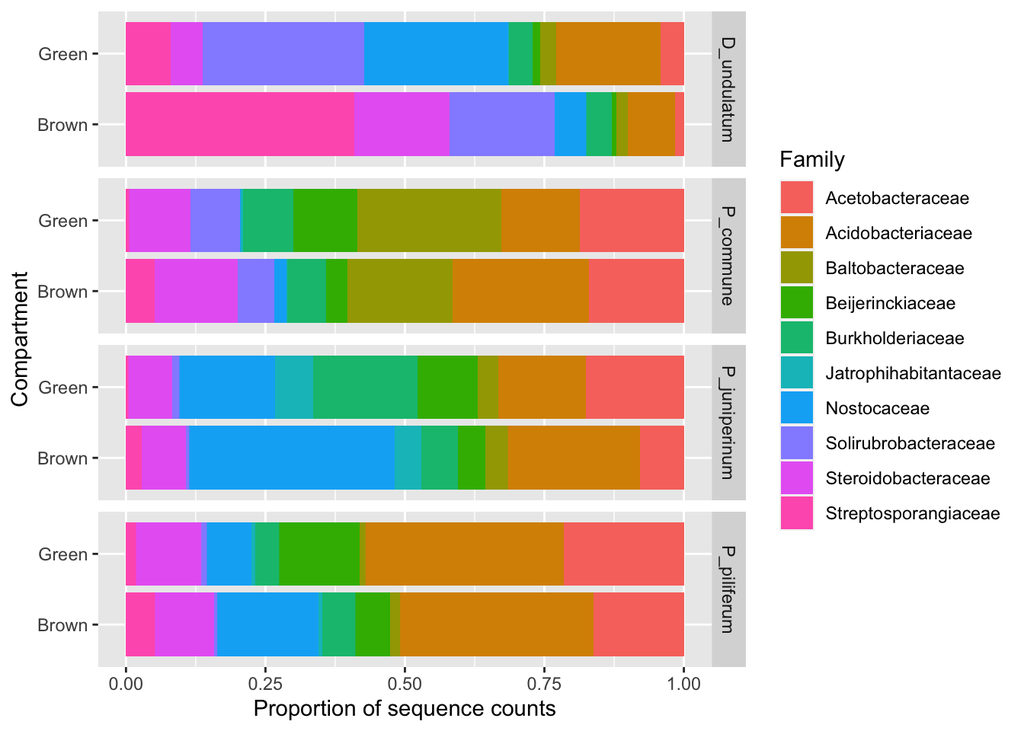

```r
ggplot(seq_count, aes(y = Compartment, x = seq_count)) +
  geom_col(aes(fill = Family),
           position = 'fill') + # normalises total values to 1
  facet_grid(rows = vars(Host)) +
  xlab("Proportion of sequence counts") # not absolute values
```

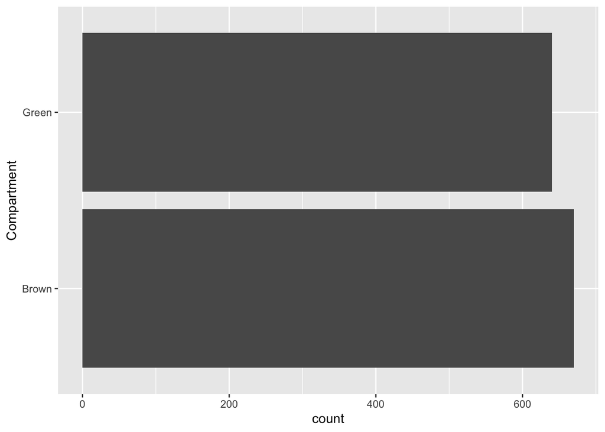

```r
ggplot(seq_count, aes(y = Compartment)) +
  geom_bar()
```

End of workshop.